```python
%matplotlib inline
import numpy as np
import matplotlib
import matplotlib.pyplot as plt
import scipy
from scipy import stats
```

# Problem 1

In lecture and homework we explored how the convolution can be used to calculate the probability of a sum or average. For this problem we are going to imagine that we are looking for gamma-ray sources (e.g. with the Fermi telescope). In this kind of telescope there is a background of cosmic-rays (electrons and protons, mostly) that provides a discrete noise term across the sky that precisely follows a Poisson distribution. To detect a gamma-ray source, you need to ask what is the probability that the cosmic-ray background would have given you a measurement as signal-like or more than the signal that you received.

To set up the problem, assume in 1 day the average cosmic-ray background is some number X (pick someting btwn 0.5 and 10, with different values for you and your lab partner); and the average number of gamma-rays emitted by your hypothetical source is Y (pick something larger than X).

A) Show how the probability distribution of the background changes as you integrate (sum) for more days.

B) Show that after 5 days, the summed probability distribution is still a Poisson distribution. Explain why this makes sense from a mathematical and conceptual point of view.

C) Show how the probability distribution evolves as you average days. Calculate for many different ranges of days, and explore the shape of the distribution as the number of days becomes larger. Discuss this in relation to both B) and the central limit theoem.

D) Pick some number of days N, and assume you saw Y*N gamma rays from your source. Calculate the 'sigma' of your observation. [In reality the number of gamma-rays seen from a source will also fluctuate, but we're going to ignore that complication for a couple of labs.]

I choose X to be 6.5. Y to be 9.

```python
cos_ray = 6.5
gam_ray = 9
```

We create the PMF first.

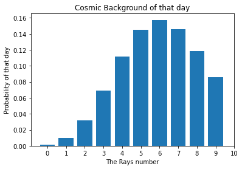

```python
pmf = stats.poisson.pmf(np.arange(0, 10), 6.5)
fig = plt.bar(xbase, pmf, label='poisson pmf')
plt.title("Cosmic Background of that day")
plt.xlabel("The Rays number")
plt.ylabel("Probability of that day")
plt.xticks(np.arange(0, 10+1, 1))
plt.show()
```

First, we define a function to plot the sum. We will use this function several times later.

```python
def plot_sum(pmf, n):
    new_pmf = pmf
    for i in range(n - 1):
        new_pmf = np.convolve(new_pmf, pmf)

    x = np.arange(xbase[0]*n, xbase[-1]*n+1)
    fig = plt.bar(x, new_pmf)
```

We plot the sum of 5 days

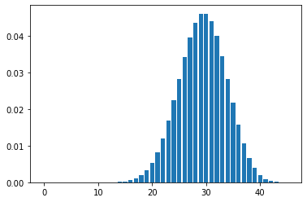

```python
n = 5
plot_sum(pmf, n)
```

The sum of Poisson distribution is still a Poisson distribution.From Probability Generating Function of Poisson Distribution, we have that the probability generating functions of X and Y are given by: ΠX(s)=e−λ1(1−s) ΠY(s)=e−λ2(1−s) respectively. Now because of their independence, we have: ΠX+Y(s) = ΠX(s)ΠY(s) PGF of Sum of Independent Discrete Random Variables = e−λ1(1−s)e−λ2(1−s) Definition of X and Y  
= e−(λ1+λ2)(1−s) Exponential of Sum

This is the probability generating function for a discrete random variable with a Poisson distribution: Poisson(λ1+λ2) Therefore: X+Y∼Poisson(λ1+λ2) Source: wikepedia(https://proofwiki.org/wiki/Sum_of_Independent_Poisson_Random_Variables_is_Poisson)

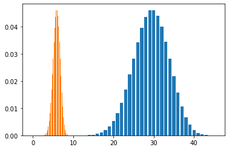

```python
n = 5
plot_sum(pmf,n)
x = np.arange(xbase[0]*n, xbase[-1]*n+1)
x = np.divide(x, n)
fig = plt.bar(x, sumpmf, width=0.15)
plt.show()
```

```python
def add_sum(pmf, n):
    new_pmf = pmf
    for i in range(n - 1):
        new_pmf = np.convolve(new_pmf, pmf)
```

So I randomly choose parameters be 60 in the new distribution to find the possible relationships

[figure not shown]

```python
n = 60
sumpmf = pmf
add_sum(sumpmf,n)

x = np.arange(xbase[0]*n, xbase[-1]*n+1)
x = np.divide(x, n)
fig = plt.bar(x, sumpmf, width=0.1)
plt.show()
```

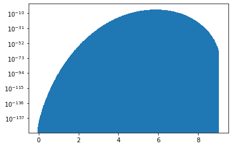

```python
plt.yscale('log')
fig = plt.bar(x, sumpmf, width=0.1)
plt.show()
```

I would say that when the parameter increase the Poisson distribution as more like normal distribution. Also, in statistics, if there is a Poisson distribution, say Poisson(n*p) , we can approximate the Poisson dist with Binomial(n,p). Then, followed by the central limit theorem for binomial random variables, Let 0<P<1 be fixed and suppose that Sn~Binomial(n,p), we can approximate Sn with normal distribution with parameter(n*p, n*p*(1-p))

So I choose number of days to be 15

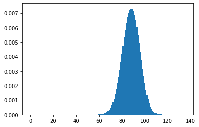

```python
n = 15
sumpmf = pmf
for i in range(n-1):
    sumpmf = np.convolve(sumpmf, pmf)

x = np.arange(xbase[0]*n, xbase[-1]*n+1)
fig = plt.bar(x, sumpmf, width=1)
```

I choose N to be 15( 15 days) So the number of gamma ray in total is 15 *9 = 135 The number of cosmic ray is 15* 6.5 = 97.5。 Put them into the distribution parameters and find the σ

```python
probability_15_day = stats.poisson(135).sf(97.5 - 1)
print(probability_15_day)
```

```
0.99974764220206
```

So the probability of it is 0.99974764220206

```python
stats.norm.ppf(1 - probability_15_day)
```

```
-3.4782411741070853
```

# Problem 2

Pick a skewed continuous distribtuion, such as a Rayleigh, that describes your background over some observing interval.

A) Show how the distribution changes as you average over more observing intervals.

B) Discuss how the shape changes. Does it approach a Gaussian distribution? If yes, after how many intervals?

For me, I assume that I have a Rayleigh distribution over interval 0 to 10 and its parameter is 1

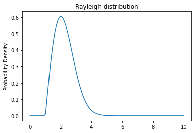

```python
rayl = stats.rayleigh(1)
x = np.linspace(0, 10, 100)
pdf = stats.rayleigh.pdf(x)
plt.title("Rayleigh distribution")
plt.ylabel("Probability Density")
plt.plot(x, dist.pdf(x))
```

```python
def sum_pdf(pdf,num):
    sumpdf = pdf
    for i in range(n-1):
        sumpdf = np.convolve(sumpdf, pdf)
```

```python
sum_pdf(5,pdf)
x = np.arange(-1,10,0.001)
pdf = stats.rayleigh.pdf(x)*0.001
x = np.linspace(-1,10, sumpdf.size)
fig = plt.plot(x, sumpdf, label="Summed of 5 Reyleigh Dist")
```

[output not shown]

```python
def avg_rayl_plot(x,pdf,n):
    new_pdf = pdf
    for i in range(n):
        new_pdf = np.convolve(new_pdf, pdf)
    plt.plot(np.linspace(x[0], x[-1], len(new_pdf)), new_pdf)
    plt.xlim(x[0], x[-1])
```

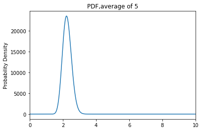

```python
pdf = dist.pdf(x)
n = 5
avg_rayl_plot(x, pdf, n)
plt.title("PDF,average of 5")
plt.ylabel("Probability Density")
```

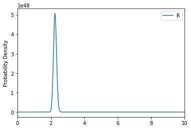

```python
pdf = dist.pdf(x)
n = 50
avg_rayl_plot(x, pdf, n)
plt.ylabel("Probability Density")
plt.legend("Rayleigh dist, sum of 50")
```

For this part I believe when I increase the value of n, the graph should be more like a Gaussian distribution. However, my computer's RAM cannot handle the casewith a large n. So I use a relatively large n, say 100.

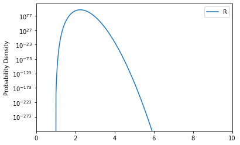

```python
n = 100
avg_rayl_plot(x, pdf, n)
plt.ylabel("Probability Density")
plt.yscale('log')
plt.legend("Rayleigh dist, sum of 100")
```

# Problem 3 Version 1

Problem 3 The discovery of optical/infra-red counterparts of Neutron star mergers initially detected with gravity-waves is one of the great discoverys in the last few years (wikipedia, scientific paper), and has ushered in the age of "multi-messenger astrophysics." The science that can be done by matching a gravity-wave signal (directly measures the mass of the neutron stars and their distance) with the optical emisson (redshift, nuclear astrophysics of the resulting explosion) is staggering. Lots of science from how the heaviest elements are formed to constraints on Dark Energy.

We're going to explore one of the analysis questions that comes up when looking for the optical counterparts (a new optical source) of a gravity wave signal. For this problem let's assume that we are using an optical telescope with a thermal noise background from the CCD (dark current, particularly an issue with older CCDs and/or infra-red CCDs). After flat-fielding, the background appears as a zero-mean Gaussian with constant width over the image.

Version 1 You have an alert from LIGO that is also seen in with the X-ray/ultra-violet satellite SWIFT. SWIFT gives you a very precise location, so you take an image of that part of the sky. But because of SWIFT's accuracy, you know which pixel in your image to look for a counterpart in.

A) From looking at all the other pixels in your image, you can measure the width of the background Gaussian distribution X (pick something). Assuming you see a signal of strength Y (pick a floating-point number; optical CCDs are not sensitive enough to count photons so the readings are floating point brightnesses, not integer photons). Calculate the significance of your detection. Can you claim a discovery (traditionally 5-sigma or more)?

For this part, I pick my X to be 3 and Y to be 3.33

```python
prob = 1-stats.norm.cdf(3.33, scale = 3)
sig = stats.norm.ppf(1-prob)
print(prob)
```

```
0.13349951324274723
```

The probability found is approximate 0.13349951324274723

```python
print(sig)
```

```
1.1100000000000003
```

The approximate significance is approximate 1.11sigma. I would say is there is no evidence from our data that we find a discovery, since our sigma value is significanly smaller than 5.

# Ver 2

You have an alert from LIGO, but no associated detection from SWIFT. This could be because it is a black hole-black hole merger, a black hole-neutron star merger (neither seem to emit X-rays or UV light), or it could because SWIFT was indisposed at the time (wrong side of the earth in its orbit). Whatever the cause, you know what region of the sky to look in, but not which pixel.

B) If you have to look for a signal in 10k pixels, what is the probability distribution of your background? (Clearly state the statistical question, then turn that into math using your background distribution from part 1 of this problem.)

C) Taking your brightest candidate signal from the region (assume it has the same signal as in part 1), calculate the significance of your detection.

Assume the value we want to test is 7.282

```python
norm = stats.norm(scale=3)
prob = norm.sf(7.282)
print(prob)
```

```
0.007605136844390949
```

So the probability is 0.007605136844390949. Then we express it by sigma.

```python
stats.norm.ppf(1 - prob)
```

```
2.4273333333333356
```

The sigma is less than 5. I would say that there is no change in our conclusion.

# Problem 4

The statistical issue we were exploring in the previous problem is called a trials factor (sometimes known as a look-elsewhere effect). This is an important effect, as if you search through a million locations, you would expect to se ~1 one in a million event. However, it is also often over estimated how big an impact this makes on the sensitivity of a search. So in this part of the lab we are going to invert the problem.

Let us again assume we have a Gaussian background (same parameters as Problem 3).

A) Calculate the signal required for a 5-sigma detection in Version 1

B) Calculate the signal required for a 5-sigma detection in Version 2

C) Discuss how much brighter the signal must be for discoverey if you have a trials factor of 10k. Looking at your probability distributions, explain why the sensitivity penalty due to a trials factor is so low.

D) If you changed the trials factor significantly (orders of magnitude), how large is the effect on your 5-sigma sensitivity threshold?

Extra credit: If you had a different distribution shape (non-Gaussian), how would that affect the sensitivity penalty of many trials? Clearly explain.

Ver 1

I defined a intermediate method in helping find the require signal

```python
# def finder(prob,num_scale):
#     output = stats.norm.ppf(1-prob, scale = num_scale)
#     return output
def finder(prob,num_scale, distance):
    output = stats.norm.ppf((1-prob) / distance, scale = num_scale)
    return output
```

```python
sig_of_5 = 1-stats.norm.cdf(5)
num = 3
distance = 1
require = finder(sig_of_5,num,1)
print(require)
```

```
14.999999999910528
```

I would say that the signal required is 15

Ver 2

```python
# sig_of_5 = 1-stats.norm.cdf(5)
# signal = stats.norm.ppf(1-sig_of_5/10000, scale=3)
# print(signal)
# sig_of_5 = 1-stats.norm.cdf(5)
# num = 3
# signal = stats.norm.ppf(1-sig_of_5/10000, scale=3)
# print(signal)
sig_of_5 = 1-stats.norm.cdf(5)
num = 3
require = finder(1-sig_of_5,num,10000)
print(require)
```

```
-19.65161283804671
```

The require value is 19.65(approx)

```python
bright = signal/15
print(bright)
```

```
1.310107497378331
```

It should be 1.31 times of origin brighter

```python
sig_of_5 = 1-stats.norm.cdf(5)
num = 3
signal = finder(1-sig_of_5,num,100000000)
print(signal)
bright = signal/15
```

```
-23.429060110799004
```

signal required for 5 sigma is 23.4

```python
print(bright)
```

```
-1.5619373407199335
```

The brightness factor is 1.5619373407199335